# Data Analysis Project Proposal

2024-11-28

## Title: The Science of Wine: Predicting Quality from Chemical Properties

### 1. Complete the dataset

We combine “winequality-white.csv” and “winequality-red.csv” and add a new variable, `color` which represents 1 for red wine and 0 for white wine.

```r
wine_data_white = read.csv("winequality-white.csv", sep=";")

# Add the "color" variable for white wine (0 = white wine)
wine_data_white$color = 0

wine_data_red = read.csv("winequality-red.csv", sep=";")

# Add the "color" variable for red wine (1 = red wine)
wine_data_red$color = 1

# Combine the two datasets
wine_data_combined = rbind(wine_data_white, wine_data_red)

# Make sure the "quality" variable is numeric
wine_data_combined$quality <- as.numeric(wine_data_combined$quality)

str(wine_data_combined)
```

```
## 'data.frame':    6497 obs. of  13 variables:
##  $ fixed.acidity       : num  7 6.3 8.1 7.2 7.2 8.1 6.2 7 6.3 8.1 ...
##  $ volatile.acidity    : num  0.27 0.3 0.28 0.23 0.23 0.28 0.32 0.27 0.3 0.22 ...
##  $ citric.acid         : num  0.36 0.34 0.4 0.32 0.32 0.4 0.16 0.36 0.34 0.43 ...
##  $ residual.sugar      : num  20.7 1.6 6.9 8.5 8.5 6.9 7 20.7 1.6 1.5 ...
##  $ chlorides           : num  0.045 0.049 0.05 0.058 0.058 0.05 0.045 0.045 0.049 0.044 ...
##  $ free.sulfur.dioxide : num  45 14 30 47 47 30 30 45 14 28 ...
##  $ total.sulfur.dioxide: num  170 132 97 186 186 97 136 170 132 129 ...
##  $ density             : num  1.001 0.994 0.995 0.996 0.996 ...
##  $ pH                  : num  3 3.3 3.26 3.19 3.19 3.26 3.18 3 3.3 3.22 ...
##  $ sulphates           : num  0.45 0.49 0.44 0.4 0.4 0.44 0.47 0.45 0.49 0.45 ...
##  $ alcohol             : num  8.8 9.5 10.1 9.9 9.9 10.1 9.6 8.8 9.5 11 ...
##  $ quality             : num  6 6 6 6 6 6 6 6 6 6 ...
##  $ color               : num  0 0 0 0 0 0 0 0 0 0 ...
```

When it comes to “quality” variable that we are using as the target variable, we use the variable as numeric, assuming that the difference between a quality of 6 and 7 is the same as the difference between a quality of 7 and 8 and allowing to make predictions for any quality.

#### 1.2 Check For missing data

```r
# Check if there is any missing data in the dataset
anyNA(wine_data_combined)  # Returns TRUE if there are missing values
```

```
## [1] FALSE
```

```r
# Summarize missing values per column
colSums(is.na(wine_data_combined))
```

```
##        fixed.acidity     volatile.acidity          citric.acid
##                    0                    0                    0
##       residual.sugar            chlorides  free.sulfur.dioxide
##                    0                    0                    0
## total.sulfur.dioxide              density                   pH
##                    0                    0                    0
##            sulphates              alcohol              quality
##                    0                    0                    0
##                color
##                    0
```

### 2. Look into Colinearity

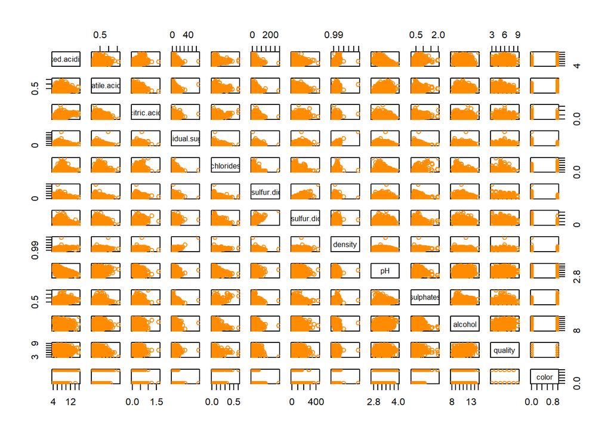

```r
library(faraway)
pairs(wine_data_combined, col = "darkorange")
```

```r
round(cor(wine_data_combined), 2)
```

```
##                      fixed.acidity volatile.acidity citric.acid residual.sugar
## fixed.acidity                 1.00             0.22        0.32          -0.11
## volatile.acidity              0.22             1.00       -0.38          -0.20
## citric.acid                   0.32            -0.38        1.00           0.14
## residual.sugar               -0.11            -0.20        0.14           1.00
## chlorides                     0.30             0.38        0.04          -0.13
## free.sulfur.dioxide          -0.28            -0.35        0.13           0.40
## total.sulfur.dioxide         -0.33            -0.41        0.20           0.50
## density                       0.46             0.27        0.10           0.55
## pH                           -0.25             0.26       -0.33          -0.27
## sulphates                     0.30             0.23        0.06          -0.19
## alcohol                      -0.10            -0.04       -0.01          -0.36
## quality                      -0.08            -0.27        0.09          -0.04
## color                         0.49             0.65       -0.19          -0.35
##                      chlorides free.sulfur.dioxide total.sulfur.dioxide density
## fixed.acidity             0.30               -0.28                -0.33    0.46
## volatile.acidity          0.38               -0.35                -0.41    0.27
## citric.acid               0.04                0.13                 0.20    0.10
## residual.sugar           -0.13                0.40                 0.50    0.55
## chlorides                 1.00               -0.20                -0.28    0.36
## free.sulfur.dioxide      -0.20                1.00                 0.72    0.03
## total.sulfur.dioxide     -0.28                0.72                 1.00    0.03
## density                   0.36                0.03                 0.03    1.00
## pH                        0.04               -0.15                -0.24    0.01
## sulphates                 0.40               -0.19                -0.28    0.26
## alcohol                  -0.26               -0.18                -0.27   -0.69
## quality                  -0.20                0.06                -0.04   -0.31
## color                     0.51               -0.47                -0.70    0.39
##                         pH sulphates alcohol quality color
## fixed.acidity        -0.25      0.30   -0.10   -0.08  0.49
## volatile.acidity      0.26      0.23   -0.04   -0.27  0.65
## citric.acid          -0.33      0.06   -0.01    0.09 -0.19
## residual.sugar       -0.27     -0.19   -0.36   -0.04 -0.35
## chlorides             0.04      0.40   -0.26   -0.20  0.51
## free.sulfur.dioxide  -0.15     -0.19   -0.18    0.06 -0.47
## total.sulfur.dioxide -0.24     -0.28   -0.27   -0.04 -0.70
## density               0.01      0.26   -0.69   -0.31  0.39
## pH                    1.00      0.19    0.12    0.02  0.33
## sulphates             0.19      1.00    0.00    0.04  0.49
## alcohol               0.12      0.00    1.00    0.44 -0.03
## quality               0.02      0.04    0.44    1.00 -0.12
## color                 0.33      0.49   -0.03   -0.12  1.00
```

Visualize Correlation Matrix with Heatmap

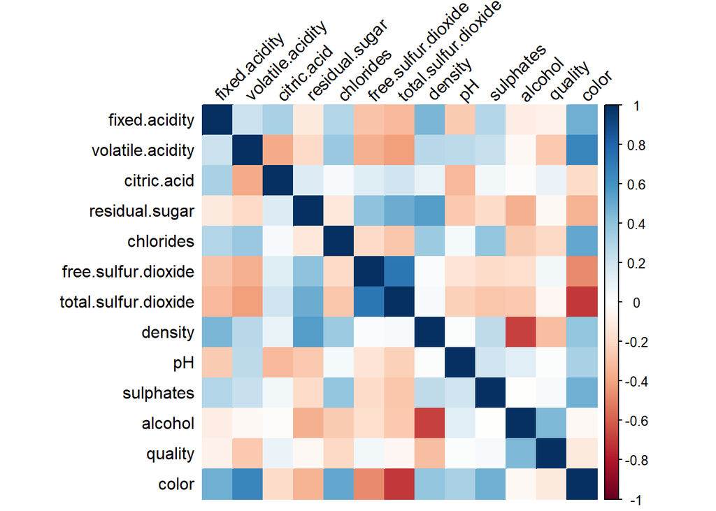

```r
library(corrplot)
cor_matrix <- cor(wine_data_combined[, sapply(wine_data_combined, is.numeric)])
corrplot(cor_matrix, method = "color", tl.col = "black", tl.srt = 45)
```

1. Correlations with the Target Variable (Qaulity) 1.1 Strongest Correlation: alcohol
- The Correlation of 0.44 is moderately positive.
- It indicates that higher alcohol content is asscoviated with higher wine quality; thus, alcohole is likely a strong predictor 1.2 Weak Correlations:
- `Sulphates`, `citric.acid`, and `free.sulfur.dioxide` have a weak or negligible correlation with `quality`.
- These may not significantly contribute to predicting wine quality unless interacions are involved. 1.3 Negative Correlations:
- `volatile.acidity` with $r=-0.27$ indicates that a higher valatile acidity (associated with wine spoilage) lowers the overall quality.
- `density` with $r=-0.31$ shows that the higher density correlates with lower quality. Improper fermantation or excessive sugar contents could possily plays a role here.
2. Multicollinearity Between Predictors 2.1 Higher Correlated Predictors
- `total.sulfur.dioxide` and `free.sulfur.dioxide` have a high corraltion with $r=0.72$. We can consider using one or combining them.
- `volatile.acidity` and `color` with $r=0.65$ also have significant correlation. Red wine (`color = 1`) might tend to have higher volatile acidity. 2.2 Some Correlations
- `fixed.acidity` and `density` with $r=0.46$ are positively correlated, likely because higher acidity contributes to higher density.
- `color` and `chlorides` with $r=0.51$. Red wine appears to have higher chloride levels on average.

3 Little Correlation - `pH` and `Sulphates` show minimal correlation with `quality`, $r=0.02$ and $r=0.04$ respectively.

#### 2.2 Testing baseline model based on Correlations

Assuming that the correlations exist, the predictors are `alcohol`, `volatile.acidity`, `density`, and `color`.

```r
lm_baseline <- lm(quality ~ alcohol + volatile.acidity + density + color, data = wine_data_combined)
summary(lm_baseline)
```

```
##
## Call:
## lm(formula = quality ~ alcohol + volatile.acidity + density +
##     color, data = wine_data_combined)
##
## Residuals:
##     Min      1Q  Median      3Q     Max
## -3.4007 -0.4777 -0.0355  0.4762  3.0633
##
## Coefficients:
##                   Estimate Std. Error t value Pr(>|t|)
## (Intercept)      -26.65696    4.98874  -5.343 9.43e-08 ***
## alcohol            0.36874    0.01142  32.303  < 2e-16 ***
## volatile.acidity  -1.67659    0.07433 -22.558  < 2e-16 ***
## density           29.29930    4.92980   5.943 2.94e-09 ***
## color              0.13054    0.03100   4.211 2.58e-05 ***
## ---
## Signif. codes:  0 '***' 0.001 '**' 0.01 '*' 0.05 '.' 0.1 ' ' 1
##
## Residual standard error: 0.7467 on 6492 degrees of freedom
## Multiple R-squared:  0.2693, Adjusted R-squared:  0.2689
## F-statistic: 598.2 on 4 and 6492 DF,  p-value: < 2.2e-16
```

**Model Summary** Residual Standard Error of 0.7467 incicates that the average deviation of the observed quality socres from the predicted values. Multiple R-Squared of 0.2693 shows that only around 27% of the variation in quality is explained by this model. Adjusted R-Square of 0.2689 shows that the model is not overfitting but is limited in explainin variability. F-Statistic of 598.2 indicate that at least one predictor is strongly associated with the response as the model is highly significant $p = 2.2*10^{-16}$.

**Test for Significance of Density Predictor** Use ANOVA to check if it makes a significant difference

```r
model_wo_density <- lm(quality ~ alcohol + volatile.acidity + color, data = wine_data_combined)

anova(lm_baseline, model_wo_density)
```

```
## Analysis of Variance Table
##
## Model 1: quality ~ alcohol + volatile.acidity + density + color
## Model 2: quality ~ alcohol + volatile.acidity + color
##   Res.Df    RSS Df Sum of Sq      F    Pr(>F)
## 1   6492 3619.6
## 2   6493 3639.3 -1   -19.694 35.323 2.938e-09 ***
## ---
## Signif. codes:  0 '***' 0.001 '**' 0.01 '*' 0.05 '.' 0.1 ' ' 1
```

A p-value of 2.938e-09 is significant, indicating that the difference resulting from removing the density predictor is significant. Therefore, the model is better off with density included than not.

**Test For Multicollinearity:** Use VIF to confirm the Multicollinearity

```r
library(car)
vif(lm_baseline)
```

```
##          alcohol volatile.acidity          density            color
##         2.159718         1.744553         2.546102         2.078048
```

VIF Scores: - All predictors have VIF < 5 showing no serious multicollonearity issues; thus, no predictors need to be removed based on the VIF.

Now, we will experiment with models using different interaction terms of the four non-collinear variables shown above (alcohol, color, density, and volatile.acidity) to see what would be an optimal model.

```r
model2 <- lm(quality ~ (alcohol + volatile.acidity + density + color)^2, data = wine_data_combined)

summary(model2)
```

```
##
## Call:
## lm(formula = quality ~ (alcohol + volatile.acidity + density +
##     color)^2, data = wine_data_combined)
##
## Residuals:
##     Min      1Q  Median      3Q     Max
## -3.4376 -0.4901 -0.0126  0.4564  3.1146
##
## Coefficients:
##                            Estimate Std. Error t value Pr(>|t|)
## (Intercept)              -229.86085   29.23516  -7.862 4.38e-15 ***
## alcohol                    19.70812    2.96677   6.643 3.32e-11 ***
## volatile.acidity           -0.20890   22.80012  -0.009   0.9927
## density                   234.93821   29.41164   7.988 1.61e-15 ***
## color                       1.74862   13.31360   0.131   0.8955
## alcohol:volatile.acidity    0.33770    0.07144   4.727 2.33e-06 ***
## alcohol:density           -19.56502    2.99164  -6.540 6.63e-11 ***
## alcohol:color              -0.05562    0.02967  -1.874   0.0609 .
## volatile.acidity:density   -5.48942   22.60038  -0.243   0.8081
## volatile.acidity:color      0.78141    0.15808   4.943 7.88e-07 ***
## density:color              -1.28356   13.19436  -0.097   0.9225
## ---
## Signif. codes:  0 '***' 0.001 '**' 0.01 '*' 0.05 '.' 0.1 ' ' 1
##
## Residual standard error: 0.7406 on 6486 degrees of freedom
## Multiple R-squared:  0.2818, Adjusted R-squared:  0.2807
## F-statistic: 254.5 on 10 and 6486 DF,  p-value: < 2.2e-16
```

```r
model3 <- lm(quality ~ (alcohol + volatile.acidity + density + color)^3, data = wine_data_combined)

summary(model2)
```

[output not shown]

```
##
## Call:
## lm(formula = quality ~ (alcohol + volatile.acidity + density +
##     color)^2, data = wine_data_combined)
##
## Residuals:
##     Min      1Q  Median      3Q     Max
## -3.4376 -0.4901 -0.0126  0.4564  3.1146
##
## Coefficients:
##                            Estimate Std. Error t value Pr(>|t|)
## (Intercept)              -229.86085   29.23516  -7.862 4.38e-15 ***
## alcohol                    19.70812    2.96677   6.643 3.32e-11 ***
## volatile.acidity           -0.20890   22.80012  -0.009   0.9927
## density                   234.93821   29.41164   7.988 1.61e-15 ***
## color                       1.74862   13.31360   0.131   0.8955
## alcohol:volatile.acidity    0.33770    0.07144   4.727 2.33e-06 ***
## alcohol:density           -19.56502    2.99164  -6.540 6.63e-11 ***
## alcohol:color              -0.05562    0.02967  -1.874   0.0609 .
## volatile.acidity:density   -5.48942   22.60038  -0.243   0.8081
## volatile.acidity:color      0.78141    0.15808   4.943 7.88e-07 ***
## density:color              -1.28356   13.19436  -0.097   0.9225
## ---
## Signif. codes:  0 '***' 0.001 '**' 0.01 '*' 0.05 '.' 0.1 ' ' 1
##
## Residual standard error: 0.7406 on 6486 degrees of freedom
## Multiple R-squared:  0.2818, Adjusted R-squared:  0.2807
## F-statistic: 254.5 on 10 and 6486 DF,  p-value: < 2.2e-16
```

```r
model4 <- lm(quality ~ (alcohol + volatile.acidity + density + color)^4, data = wine_data_combined)

summary(model4)
```

```
##
## Call:
## lm(formula = quality ~ (alcohol + volatile.acidity + density +
##     color)^4, data = wine_data_combined)
##
## Residuals:
##     Min      1Q  Median      3Q     Max
## -3.4704 -0.4801 -0.0178  0.4580  3.1545
##
## Coefficients:
##                                         Estimate Std. Error t value Pr(>|t|)
## (Intercept)                             -511.300     88.291  -5.791 7.32e-09
## alcohol                                   46.380      8.034   5.773 8.14e-09
## volatile.acidity                         869.151    282.468   3.077 0.002100
## density                                  519.104     88.796   5.846 5.28e-09
## color                                   1087.348    297.402   3.656 0.000258
## alcohol:volatile.acidity                 -78.445     24.600  -3.189 0.001435
## alcohol:density                          -46.503      8.084  -5.752 9.22e-09
## alcohol:color                           -104.683     27.092  -3.864 0.000113
## volatile.acidity:density                -882.831    283.982  -3.109 0.001887
## volatile.acidity:color                 -2150.135    618.935  -3.474 0.000516
## density:color                          -1095.568    298.544  -3.670 0.000245
## alcohol:volatile.acidity:density          79.538     24.740   3.215 0.001311
## alcohol:volatile.acidity:color           204.312     56.388   3.623 0.000293
## alcohol:density:color                    105.471     27.204   3.877 0.000107
## volatile.acidity:density:color          2169.465    621.462   3.491 0.000485
## alcohol:volatile.acidity:density:color  -206.098     56.632  -3.639 0.000276
##
## (Intercept)                            ***
## alcohol                                ***
## volatile.acidity                       **
## density                                ***
## color                                  ***
## alcohol:volatile.acidity               **
## alcohol:density                        ***
## alcohol:color                          ***
## volatile.acidity:density               **
## volatile.acidity:color                 ***
## density:color                          ***
## alcohol:volatile.acidity:density       **
## alcohol:volatile.acidity:color         ***
## alcohol:density:color                  ***
## volatile.acidity:density:color         ***
## alcohol:volatile.acidity:density:color ***
## ---
## Signif. codes:  0 '***' 0.001 '**' 0.01 '*' 0.05 '.' 0.1 ' ' 1
##
## Residual standard error: 0.7379 on 6481 degrees of freedom
## Multiple R-squared:  0.2877, Adjusted R-squared:  0.286
## F-statistic: 174.5 on 15 and 6481 DF,  p-value: < 2.2e-16
```

Looking at the revised models including only the significant terms from the 2, 3, and 4 way interaction models, and comparing them to the baseline model, gives us this:

```r
model_red2 <- lm(
  quality ~ alcohol + density + alcohol:volatile.acidity + alcohol:density + volatile.acidity:color,
  data = wine_data_combined
)

model_red3 <- lm(
  quality ~ alcohol + density + alcohol:volatile.acidity:color,
  data = wine_data_combined
)
```

```r
bic_values <- data.frame(
  Model = c("lm_baseline", "model_red2", "model_red3", "model4"),
  BIC = c(BIC(lm_baseline), BIC(model_red2), BIC(model_red3), BIC(model4))
)

print(bic_values)
```

```
##         Model      BIC
## 1 lm_baseline 14689.83
## 2  model_red2 14662.29
## 3  model_red3 15064.70
## 4      model4 14621.04
```

The 4 way interaction model has the smallest BIC value, despite it being the most complex.  
Now, let’s run a bi-directional step function to find what R thinks is the optimal model. Then, we will compare this to the best of the models from above, which is the 4 way interaction model.

```r
max_model <- lm(quality ~ (alcohol + volatile.acidity + density + color)^4, data = wine_data_combined)

null_model <- lm(quality ~ 1, data = wine_data_combined)

step_model <- step(lm_baseline, scope = list(lower = null_model, upper = max_model), direction = "both", trace = 1)
```

```
## Start:  AIC=-3790.53
## quality ~ alcohol + volatile.acidity + density + color
##
##                            Df Sum of Sq    RSS     AIC
## + alcohol:density           1     32.44 3587.2 -3847.0
## + volatile.acidity:color    1     13.29 3606.3 -3812.4
## + alcohol:volatile.acidity  1      7.12 3612.5 -3801.3
## + alcohol:color             1      3.80 3615.8 -3795.4
## + volatile.acidity:density  1      3.39 3616.2 -3794.6
## <none>                                  3619.6 -3790.5
## + density:color             1      0.05 3619.6 -3788.6
## - color                     1      9.89 3629.5 -3774.8
## - density                   1     19.69 3639.3 -3757.3
## - volatile.acidity          1    283.71 3903.3 -3302.3
## - alcohol                   1    581.79 4201.4 -2824.1
##
## Step:  AIC=-3847.02
## quality ~ alcohol + volatile.acidity + density + color + alcohol:density
##
##                            Df Sum of Sq    RSS     AIC
## + volatile.acidity:color    1    13.805 3573.4 -3870.1
## + alcohol:volatile.acidity  1    11.853 3575.3 -3866.5
## <none>                                  3587.2 -3847.0
## + volatile.acidity:density  1     0.493 3586.7 -3845.9
## + density:color             1     0.065 3587.1 -3845.1
## + alcohol:color             1     0.018 3587.2 -3845.1
## - color                     1    17.947 3605.1 -3816.6
## - alcohol:density           1    32.440 3619.6 -3790.5
## - volatile.acidity          1   298.643 3885.8 -3329.5
##
## Step:  AIC=-3870.07
## quality ~ alcohol + volatile.acidity + density + color + alcohol:density +
##     volatile.acidity:color
##
##                            Df Sum of Sq    RSS     AIC
## + alcohol:volatile.acidity  1    13.358 3560.0 -3892.4
## + volatile.acidity:density  1     3.483 3569.9 -3874.4
## <none>                                  3573.4 -3870.1
## + alcohol:color             1     0.212 3573.2 -3868.5
## + density:color             1     0.135 3573.3 -3868.3
```

[output cut: 26 more lines]

```
## - volatile.acidity:color          1   14.4181 3572.0 -3870.6
## - alcohol:volatile.acidity        1   15.5855 3573.2 -3868.5
## - alcohol:density                 1   27.3757 3585.0 -3847.1
##
## Step:  AIC=-3920.94
## quality ~ alcohol + volatile.acidity + density + color + alcohol:density +
##     volatile.acidity:color + alcohol:volatile.acidity + alcohol:color +
##     alcohol:volatile.acidity:color
##
##                                  Df Sum of Sq    RSS     AIC
## <none>                                        3542.3 -3920.9
## + density:color                   1    0.0453 3542.2 -3919.0
## + volatile.acidity:density        1    0.0364 3542.2 -3919.0
## - alcohol:volatile.acidity:color  1   15.3444 3557.6 -3894.9
## - alcohol:density                 1   23.8684 3566.1 -3879.3
```

```r
summary(step_model)
```

```
##
## Call:
## lm(formula = quality ~ alcohol + volatile.acidity + density +
##     color + alcohol:density + volatile.acidity:color + alcohol:volatile.acidity +
##     alcohol:color + alcohol:volatile.acidity:color, data = wine_data_combined)
##
## Residuals:
##     Min      1Q  Median      3Q     Max
## -3.4745 -0.4769 -0.0208  0.4578  3.1197
##
## Coefficients:
##                                  Estimate Std. Error t value Pr(>|t|)
## (Intercept)                    -215.25391   29.22287  -7.366 1.98e-13 ***
## alcohol                          18.67165    2.79698   6.676 2.67e-11 ***
## volatile.acidity                 -8.51075    0.86452  -9.844  < 2e-16 ***
## density                         221.14603   29.37570   7.528 5.84e-14 ***
## color                            -2.71038    0.65709  -4.125 3.76e-05 ***
## alcohol:density                 -18.60785    2.81451  -6.611 4.11e-11 ***
## volatile.acidity:color            8.20966    1.41141   5.817 6.29e-09 ***
## alcohol:volatile.acidity          0.60734    0.08136   7.465 9.44e-14 ***
## alcohol:color                     0.24608    0.06182   3.980 6.96e-05 ***
## alcohol:volatile.acidity:color   -0.70742    0.13345  -5.301 1.19e-07 ***
## ---
## Signif. codes:  0 '***' 0.001 '**' 0.01 '*' 0.05 '.' 0.1 ' ' 1
##
## Residual standard error: 0.739 on 6487 degrees of freedom
## Multiple R-squared:  0.2849, Adjusted R-squared:  0.2839
## F-statistic: 287.2 on 9 and 6487 DF,  p-value: < 2.2e-16
```

**Conduct Checks on the Stepwise Model**

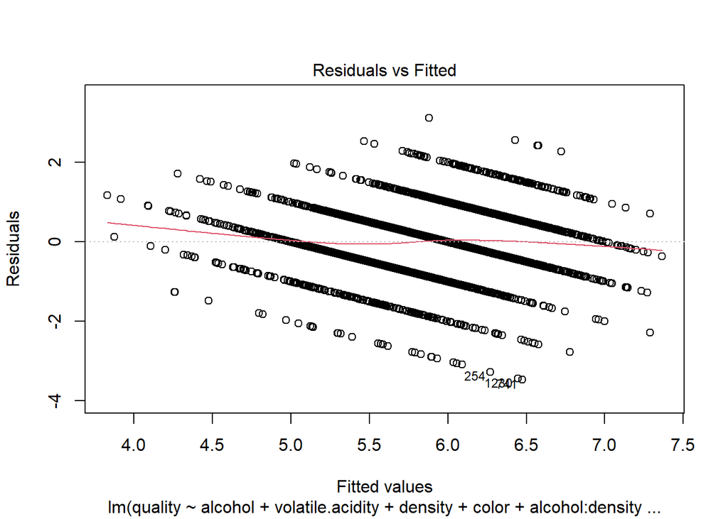

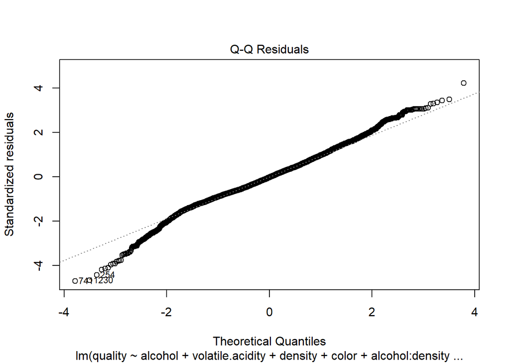

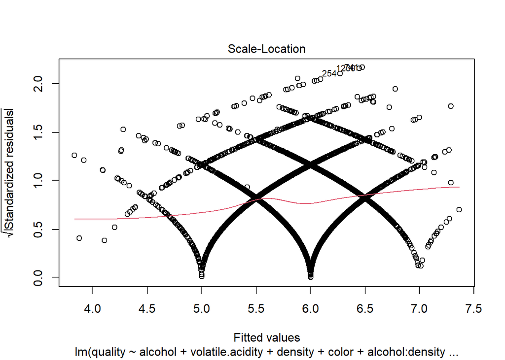

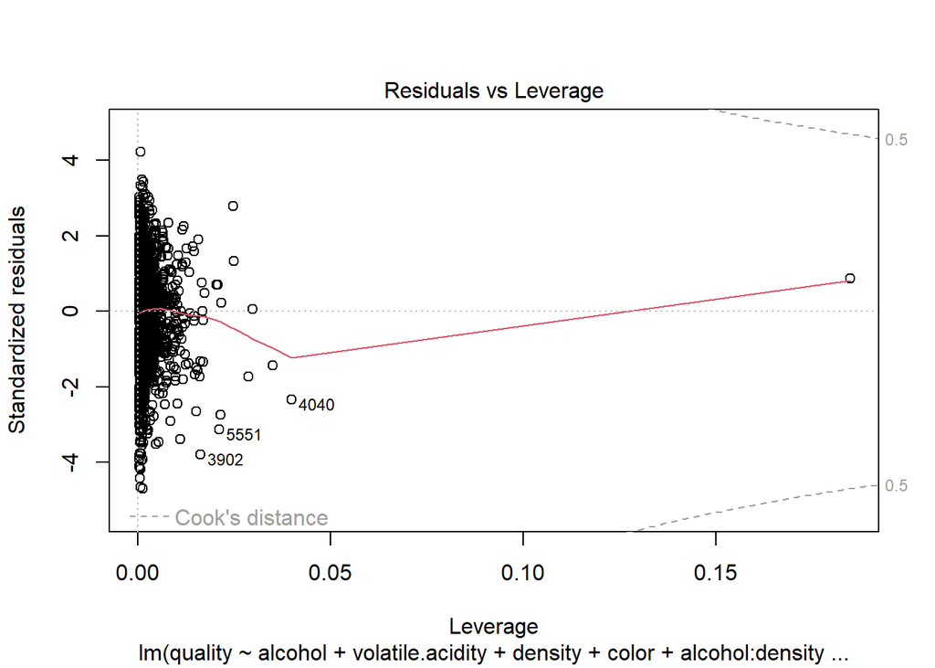

```r
plot(step_model)
```

```r
vif(step_model, type = 'predictor')
```

```
## GVIFs computed for predictors
```

```
##                          GVIF Df GVIF^(1/(2*Df))
## alcohol               1.00000  9        1.000000
## volatile.acidity 197409.59611  7        2.389134
## density              20.44674  3        1.653626
## color            197409.59611  7        2.389134
##                                    Interacts With        Other Predictors
## alcohol          density, volatile.acidity, color                    --
## volatile.acidity                   color, alcohol                 density
## density                                   alcohol volatile.acidity, color
## color                   volatile.acidity, alcohol                 density
```

```r
BIC(step_model)
```

```
## [1] 14593.32
```

```r
library(caret)
step_formula <- formula(step_model)

train_ctrl <- trainControl(method = "cv", number = 10)

cv_model <- train(step_formula,
                  data = wine_data_combined,
                  method = "lm",
                  trControl = train_ctrl)

print(cv_model)
```

```
## Linear Regression
##
## 6497 samples
##    4 predictor
##
## No pre-processing
## Resampling: Cross-Validated (10 fold)
## Summary of sample sizes: 5848, 5847, 5847, 5847, 5848, 5846, ...
## Resampling results:
##
##   RMSE       Rsquared   MAE
##   0.7396104  0.2833743  0.5748127
##
## Tuning parameter 'intercept' was held constant at a value of TRUE
```

```r
cv_model$results
```

```
##   intercept      RMSE  Rsquared       MAE     RMSESD RsquaredSD      MAESD
## 1      TRUE 0.7396104 0.2833743 0.5748127 0.01860061 0.02400144 0.01020098
```

This stepwise model seems to perform better than or about the same as the 4 way interaction model in each statistic, so using the predictors alcohol, density, color, and volatile.acidity, this will be the preferred model to use.

### 3. Build Additive Multi Linear Regression Model

We first build additive MLR model for ground work and we find that the model has low adjusted R squared and high cross-validated RMSE, we can’t say this is a good model.

```r
additive_model = lm(quality ~ ., data = wine_data_combined)

# Adjusted R Sqaured
additive_model_adjR2 = summary(additive_model)$adj.r.squared
additive_model_adjR2
```

```
## [1] 0.2952327
```

```r
# Cross-Validated RMSE
additive_model_CVRMSE = sqrt(mean((resid(additive_model) / (1 - hatvalues(additive_model))) ^ 2))
additive_model_CVRMSE
```

```
## [1] 0.7342696
```

Here, let’s take a look at influential points.

```r
sum(cooks.distance(additive_model) > 4 / length(cooks.distance(additive_model)))
```

```
## [1] 317
```

Here we find 317 influential points in our dataset and remove them which actually works!!

```r
cd = cooks.distance(additive_model)

additive_model_fix = lm(quality ~ ., data = wine_data_combined, subset = cd < 4 / length(cd))

# Adjusted R Sqaured
additive_model_adjR2 = summary(additive_model_fix)$adj.r.squared
additive_model_adjR2
```

```
## [1] 0.359182
```

```r
# Cross-Validated RMSE
additive_model_CVRMSE = sqrt(mean((resid(additive_model_fix) / (1 - hatvalues(additive_model_fix))) ^ 2))
additive_model_CVRMSE
```

```
## [1] 0.6310693
```

```r
interaction2_model = lm(quality ~ .^2, data = wine_data_combined)

cd = cooks.distance(interaction2_model)

interaction2_model_fix = lm(quality ~ .^2, data = wine_data_combined, subset = cd < 4 / length(cd))

# Adjusted R Sqaured
interaction2_model_adjR2 = summary(interaction2_model_fix)$adj.r.squared
interaction2_model_adjR2
```

```
## [1] 0.4078913
```

```r
# Cross-Validated RMSE
interaction2_model_CVRMSE = sqrt(mean((resid(interaction2_model_fix) / (1 - hatvalues(interaction2_model_fix))) ^ 2))
interaction2_model_CVRMSE
```

```
## [1] 0.6261319
```

```r
interaction3_model = lm(quality ~ .^3, data = wine_data_combined)

cd = cooks.distance(interaction3_model)

interaction3_model_fix = lm(quality ~ .^3, data = wine_data_combined, subset = cd < 4 / length(cd))

# Adjusted R Sqaured
interaction3_model_adjR2 = summary(interaction3_model_fix)$adj.r.squared
interaction3_model_adjR2
```

```
## [1] 0.450013
```

```r
# Cross-Validated RMSE
interaction3_model_CVRMSE = sqrt(mean((resid(interaction3_model_fix) / (1 - hatvalues(interaction3_model_fix))) ^ 2))
interaction3_model_CVRMSE
```

```
## [1] 0.6147435
```

```r
poly_model = lm(quality ~ .^2 + I(fixed.acidity^2) + I(volatile.acidity^2) + I(citric.acid^2) + I(residual.sugar^2) + I(chlorides^2) + I(free.sulfur.dioxide^2) + I(total.sulfur.dioxide^2) + I(density^2) + I(pH^2) + I(alcohol^2) + I(color^2), data = wine_data_combined)

cd = cooks.distance(poly_model)

poly_model_fix = lm(quality ~ .^2 + I(fixed.acidity^2) + I(volatile.acidity^2) + I(citric.acid^2) + I(residual.sugar^2) + I(chlorides^2) + I(free.sulfur.dioxide^2) + I(total.sulfur.dioxide^2) + I(density^2) + I(pH^2) + I(alcohol^2) + I(color^2), data = wine_data_combined, subset = cd < 4 / length(cd))

# Adjusted R Sqaured
poly_model_adjR2 = summary(poly_model_fix)$adj.r.squared
poly_model_adjR2
```

```
## [1] 0.418026
```

```r
# Cross-Validated RMSE
poly_model_CVRMSE = sqrt(mean((resid(poly_model_fix) / (1 - hatvalues(poly_model_fix))) ^ 2))
poly_model_CVRMSE
```

```
## [1] 0.6217052
```

### 4. Make The Response Logged

```r
response_log_model = lm(log(quality) ~ ., data = wine_data_combined)

cd = cooks.distance(response_log_model)

response_log_model_fix = lm(log(quality) ~ ., data = wine_data_combined, subset = cd < 4 / length(cd))

# Adjusted R Sqaured
response_log_model_adjR2 = summary(response_log_model_fix)$adj.r.squared
response_log_model_adjR2
```

```
## [1] 0.3629853
```

```r
# Cross-Validated RMSE
response_log_model_CVRMSE = sqrt(mean((resid(response_log_model_fix) / (1 - hatvalues(response_log_model_fix))) ^ 2))
response_log_model_CVRMSE
```

```
## [1] 0.1076591
```

### 5. Make Some Predictors Logged

```r
log_model = lm(quality ~ fixed.acidity + volatile.acidity + citric.acid + residual.sugar + chlorides + log(free.sulfur.dioxide) + log(total.sulfur.dioxide) + density + pH + sulphates + alcohol + color, data = wine_data_combined)

cd = cooks.distance(log_model)

log_model_fix = lm(quality ~ fixed.acidity + volatile.acidity + citric.acid + residual.sugar + chlorides + log(free.sulfur.dioxide) + log(total.sulfur.dioxide) + density + pH + sulphates + alcohol + color, data = wine_data_combined, subset = cd < 4 / length(cd))

# Adjusted R Sqaured
log_model_adjR2 = summary(log_model_fix)$adj.r.squared
log_model_adjR2
```

```
## [1] 0.3711539
```

```r
# Cross-Validated RMSE
log_model_CVRMSE = sqrt(mean((resid(log_model_fix) / (1 - hatvalues(log_model_fix))) ^ 2))
log_model_CVRMSE
```

```
## [1] 0.6247346
```

### 6. Try Box-Cox Transformation On The Response Variable

We shortly introduced Box-Cox Transformation in the class, but here we are going to try applying it referring to the textbook.

```r
library(MASS)

model = lm(quality ~ ., data = wine_data_combined)
cd = cooks.distance(model)

bc = boxcox(lm(quality ~ ., data = wine_data_combined, subset = cd < 4 / length(cd)))
```

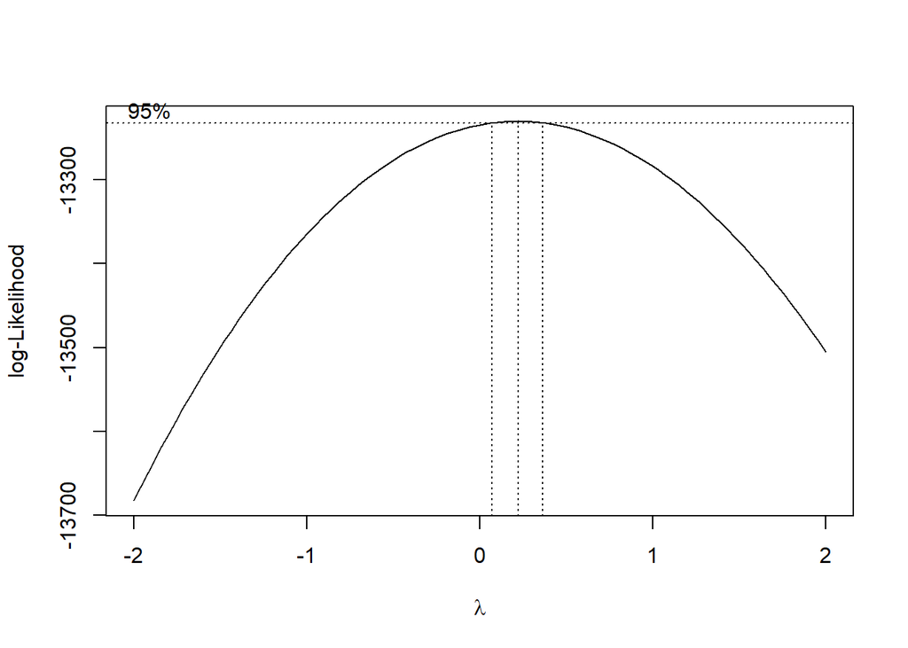

```r
lambda = bc$x[which.max(bc$y)]
quality_bc = (wine_data_combined$quality^lambda - 1) / lambda
boxcox_model = lm(quality_bc ~ ., data = wine_data_combined)

# Adjusted R Sqaured
boxcox_model_adjR2 = summary(boxcox_model)$adj.r.squared
boxcox_model_adjR2
```

```
## [1] 0.9917623
```

```r
# Cross-Validated RMSE
boxcox_model_CVRMSE = sqrt(mean((resid(boxcox_model) / (1 - hatvalues(boxcox_model))) ^ 2))
boxcox_model_CVRMSE
```

```
## [1] 0.02043242
```

### 7. Backward Model Selection

Here we first try backward selection procedure with the two-way interaction model. Then, we do backward selection procedure with the two-way interaction model again, but this time we apply Box-Cox Transformation on it. (We are supposed to try three-way interaction model as it has better performance, but it takes too long to get the model from backward selection)

```r
# Backward selection procedure with the two-way interaction model
backwardBIC_model = step(interaction2_model, direction = "backward", k = log(length(resid(interaction2_model))), trace = 0, na.action = na.omit)

backwardBIC_model_adjR2 = summary(backwardBIC_model)$adj.r.squared
backwardBIC_model_adjR2
```

```
## [1] 0.3516191
```

```r
# Cross-Validated RMSE
backwardBIC_model_CVRMSE = sqrt(mean((resid(backwardBIC_model) / (1 - hatvalues(backwardBIC_model))) ^ 2))
backwardBIC_model_CVRMSE
```

```
## [1] 0.7093458
```

```r
# Backward selection procedure with the two-way interaction model with Box-Cox Transformation

bc = boxcox(lm(quality ~ (.- color)^2, data = wine_data_combined))
```

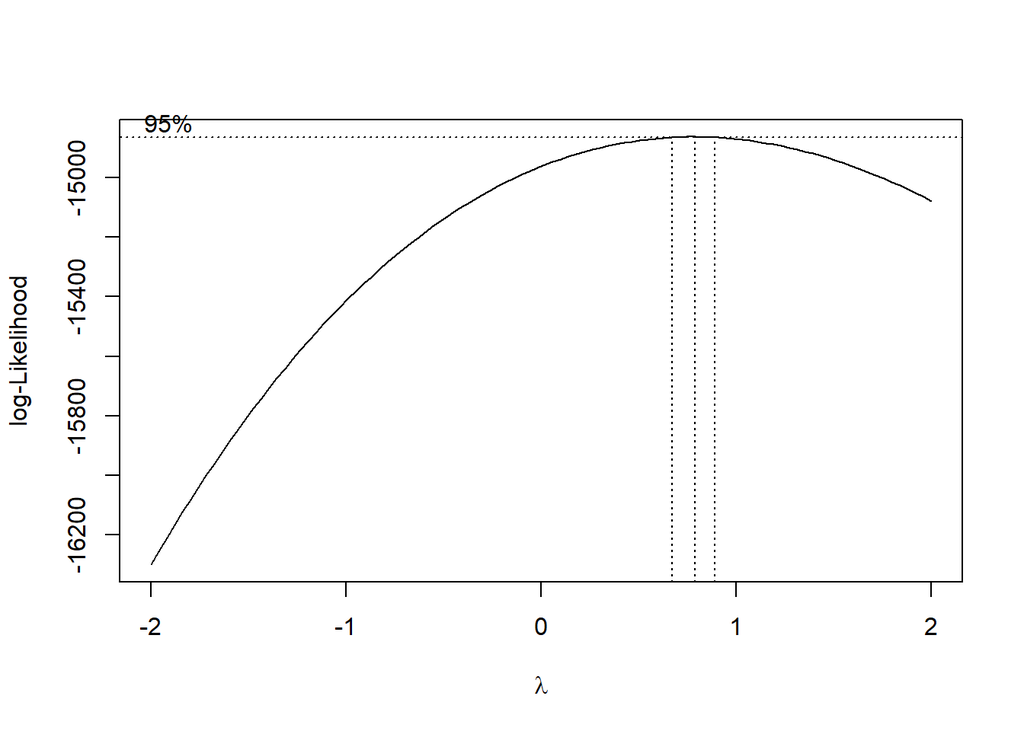

```r
lambda = bc$x[which.max(bc$y)]
quality_bc = (wine_data_combined$quality^lambda - 1) / lambda
boxcox_bigmodel = lm(quality_bc ~ (.- color)^2, data = wine_data_combined)

# Adjusted R Sqaured
boxcox_bigmodel_adjR2 = summary(boxcox_model)$adj.r.squared
boxcox_bigmodel_adjR2
```

```
## [1] 0.9917623
```

```r
# Cross-Validated RMSE
boxcox_bigmodel_CVRMSE = sqrt(mean((resid(boxcox_model) / (1 - hatvalues(boxcox_model))) ^ 2))
boxcox_bigmodel_CVRMSE
```

```
## [1] 0.02043242
```

```r
backwardBIC_bcmodel = step(boxcox_bigmodel, direction = "backward", k = log(length(resid(boxcox_bigmodel))), trace = 0)

# Adjusted R Sqaured
backwardBIC_bcmodel_adjR2 = summary(backwardBIC_model)$adj.r.squared
backwardBIC_bcmodel_adjR2
```

```
## [1] 0.3516191
```

```r
# Cross-Validated RMSE
backwardBIC_bcmodel_CVRMSE = sqrt(mean((resid(backwardBIC_bcmodel) / (1 - hatvalues(backwardBIC_bcmodel))) ^ 2))
backwardBIC_bcmodel_CVRMSE
```

```
## [1] 0.01206073
```

### 8. Choose the best model

```r
comparison_table1 =  data.frame(
  Model = c("Additive Model", "Two-Way Interaction Model", "Three-Way Interaction Model", "Quadractic Model"),
  Adjusted_R2 = c(additive_model_adjR2, interaction2_model_adjR2, interaction3_model_adjR2, poly_model_adjR2),
  CVRMSE = c(additive_model_CVRMSE, interaction2_model_CVRMSE, interaction3_model_CVRMSE, poly_model_CVRMSE)
)

print(comparison_table1)
```

```
##                         Model Adjusted_R2    CVRMSE
## 1              Additive Model   0.3591820 0.6310693
## 2   Two-Way Interaction Model   0.4078913 0.6261319
## 3 Three-Way Interaction Model   0.4500130 0.6147435
## 4            Quadractic Model   0.4180260 0.6217052
```

```r
comparison_table2 =  data.frame(
  Model = c("Logged Response Model", "Logged Predictors Model", "Box-Cox Model"),
  Adjusted_R2 = c(response_log_model_adjR2, log_model_adjR2, boxcox_model_adjR2),
  CVRMSE = c(response_log_model_CVRMSE, log_model_CVRMSE, boxcox_model_CVRMSE)
)

print(comparison_table2)
```

```
##                     Model Adjusted_R2     CVRMSE
## 1   Logged Response Model   0.3629853 0.10765907
## 2 Logged Predictors Model   0.3711539 0.62473460
## 3           Box-Cox Model   0.9917623 0.02043242
```

```r
comparison_table3 =  data.frame(
  Model = c("Backward Selection From Two-Way Interaction Model", "Backward Selection From Two-Way Interaction Model (Box-Cox)"),
  Adjusted_R2 = c(backwardBIC_model_adjR2, backwardBIC_bcmodel_adjR2),
  CVRMSE = c(backwardBIC_model_CVRMSE, backwardBIC_bcmodel_CVRMSE)
)

print(comparison_table3)
```

```
##                                                         Model Adjusted_R2
## 1           Backward Selection From Two-Way Interaction Model   0.3516191
## 2 Backward Selection From Two-Way Interaction Model (Box-Cox)   0.3516191
##       CVRMSE
## 1 0.70934580
## 2 0.01206073
```

### 9. Diagnose The Chosen Model

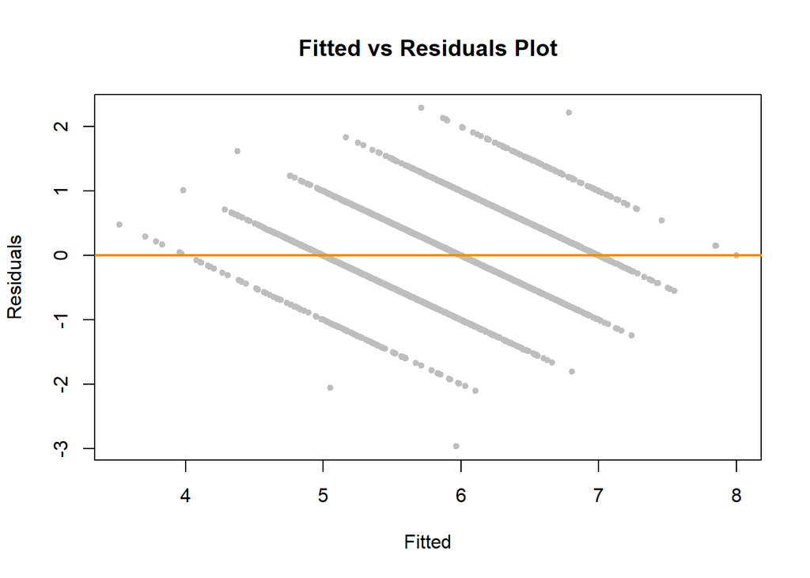

```r
plot(fitted(interaction3_model_fix), resid(interaction3_model_fix), col = "grey", pch = 20,
     xlab = "Fitted", ylab = "Residuals", main = "Fitted vs Residuals Plot")
abline(h = 0, col = "darkorange", lwd = 2)
```

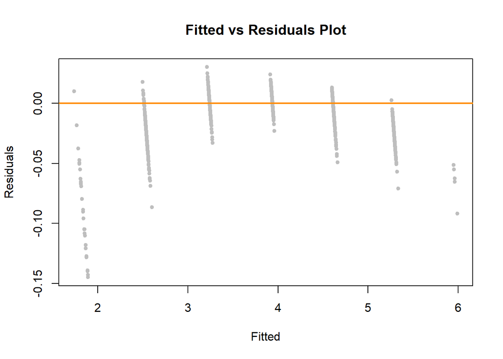

```r
plot(fitted(backwardBIC_bcmodel), resid(backwardBIC_bcmodel), col = "grey", pch = 20,
     xlab = "Fitted", ylab = "Residuals", main = "Fitted vs Residuals Plot")
abline(h = 0, col = "darkorange", lwd = 2)
```

Here we can see the issue with the structure of our data. Since our response variable “quality” is discrete, we are facing problems with the residuals because the MLR model assumes continuous data and seeing violations of homoscedasticity and linearity assumption.

```r
library(lmtest)

bptest(interaction3_model_fix)
```

```
##
##  studentized Breusch-Pagan test
##
## data:  interaction3_model_fix
## BP = 444.47, df = 298, p-value = 7.427e-08
```

```r
# We cannot use shapiro.test as the sample size is over 5000
# shapiro.test(resid(backwardBIC_model2))

# Therefore here we use Anderson-Darling test that doesn't have the same sample size restrictions

library(nortest)
ad.test(resid(interaction3_model_fix))
```

```
##
##  Anderson-Darling normality test
##
## data:  resid(interaction3_model_fix)
## A = 6.5357, p-value = 5.016e-16
```

```r
bptest(backwardBIC_bcmodel)
```

```
##
##  studentized Breusch-Pagan test
##
## data:  backwardBIC_bcmodel
## BP = 363.33, df = 39, p-value < 2.2e-16
```

```r
ad.test(resid(backwardBIC_bcmodel))
```

```
##
##  Anderson-Darling normality test
##
## data:  resid(backwardBIC_bcmodel)
## A = 525.82, p-value < 2.2e-16
```